# **Data-Driven Spatio-Temporal Reef Insights**

### **Benthic Group Shifting in the GBR**

### Environment Setup (JupyterLab Env)

First, I'll **install dependences** which weren't pre-installed in the environment image:

```python
%pip install pmdarima torch_geometric torch tbats
```

And then I'll **load the packages** and **data (without transformations)** which will be used throughout this project:

```python
import pandas as pd
import numpy as np
from pmdarima import auto_arima # Auto ARIMA;
from tbats import TBATS # TBATS;
import matplotlib.pyplot as plt
import seaborn as sns
from scipy.interpolate import CubicSpline
import networkx as nx
import datetime

# SKLearn libraries;
from sklearn.preprocessing import StandardScaler
from sklearn.metrics import mean_squared_error
from sklearn.neighbors import NearestNeighbors

# Neural network related libraries;
import pandas as pd, numpy as np, torch
from torch import nn, optim
from torch.utils.data import Dataset, DataLoader
from torch_geometric.nn import GCNConv
```

```python
# Load the primary dataset;
primary_df = pd.read_csv('./processed_data/truncated/primary_ltmp_summarised_by_benthic_group.csv')
primary_df['SAMPLE_DATE'] = pd.to_datetime(primary_df['SAMPLE_DATE'])
```

Get rid of the `Unnamed: 0` column *(not sure why thats there, and doesn't hold any information)*:

```python
primary_df = primary_df.drop('Unnamed: 0', axis=1)
```

### Interpolation of Primary Data: Spline-Based Interpolation

It should be noted that **`primary_df`**, in its raw form, is yearly data. This may be an issue in most scenaios, but since we understand the context that the data represents **coral reef benthic group shifting**, there are some safe assumptions that we can make; the most important of which is that there is unlikely to be much variation between temporal intervals.

Based on that assumption, I applied **spline-based interpolation** here to re-sample the data into **weekly data**; *this should allow for the current yearly data to be resampled to a **weekly** rate*. A **global date range** is determined first *by finding overlapping periods across all reefs, ensuring interpolations are aligned to **weekly BY MONDAY** intervals*. **Cubic splines** are then used to **interpolate and fill gaps** in the **benthic group cover data** within that global timeframe, avoiding extrapolation outside the known range. To introduce **variability**, **Gaussian noise** is added, and **random scaling factors** are applied, which should mimick natural fluctuations and prevent models from learning the interpolation rather than the data at hand.

Here is my implementation of such a solution:

```python
# (ensure repeatability);
np.random.seed(42)

# Noise and scaling configuration settings;
noise_std = 0.25  # Standard deviation for Gaussian noise;
    # (when noise factor is too aggressive, negative invalid values are seen, be careful with this);
scaling_factor_range = (0.97, 1.03) # Random scaling factor range for variation;
    # (could heavily alter RMSE results, don't make this too aggressive either);

temp_df = primary_df.copy()
temp_df['SAMPLE_DATE'] = pd.to_datetime(temp_df['SAMPLE_DATE'])
temp_df = temp_df.sort_values(by=["REEF_NAME", "SAMPLE_DATE"])

# Identify the cover columns;
cover_cols = [col for col in temp_df.columns if col.endswith("_COVER")]
if len(cover_cols) != 4:
    raise ValueError("Expected exactly 4 COVER columns. Found: {}".format(cover_cols))

# Determine the global common date range;
    # (this will ensure that the "earliest end date" and the "latest start date" are used to adjust teh results);
    # (print out the global start and global end for future reference);
date_ranges = temp_df.groupby('REEF_NAME')['SAMPLE_DATE'].agg(['min','max']).reset_index()
global_start = date_ranges['min'].max()
global_end = date_ranges['max'].min()
print(f"Global Start: {global_start}")
print(f"Global End: {global_end}")

# Throw error if range is invalid;
if global_start > global_end:
    raise ValueError("No overlapping date range found for all reefs.")

# Align global_start to the chosen weekday if needed.
    # (pd.date_range with freq='W-MON' starts from the first Monday on or after global_start);
global_weekly_dates = pd.date_range(start=global_start, end=global_end, freq='W-MON')

# Prepare a list to hold results
results = []

for reef_id, group in temp_df.groupby("REEF_NAME"):
    group = group.sort_values(by="SAMPLE_DATE")

    # Extract `x` as ordinal days;
    x = group["SAMPLE_DATE"].map(datetime.datetime.toordinal).values
    # Fit cubic splines for each cover column;
    splines = {}
    for c in cover_cols:
        y = group[c].values
        splines[c] = CubicSpline(x, y, extrapolate=False) # No extrapolation;

    # Convert global weekly dates to ordinal;
    x_new = global_weekly_dates.map(datetime.datetime.toordinal).values
    # Interpolate each cover column for the global weekly dates;
    interpolated_data = { "REEF_NAME": [reef_id]*len(global_weekly_dates),
                          "SAMPLE_DATE": global_weekly_dates }
    for c in cover_cols:
        interpolated_data[c] = splines[c](x_new)

    # Add Gaussian noise and scaling variation;
    covers_array = np.column_stack([interpolated_data[c] for c in cover_cols])
    # Add noise;
    noise = np.random.normal(loc=0, scale=noise_std, size=covers_array.shape)
    covers_array_noisy = covers_array + noise
    # Add random scaling factor per row;
    scale_factors = np.random.uniform(scaling_factor_range[0], scaling_factor_range[1], size=len(global_weekly_dates))
    covers_array_scaled = covers_array_noisy * scale_factors[:, None]

    # Normalize to sum to 100 (since cover values sum to 100%);
    sums = covers_array_scaled.sum(axis=1, keepdims=True)
    covers_array_final = (covers_array_scaled / sums) * 100.0

    # Store final results;
    for i, c in enumerate(cover_cols):
        interpolated_data[c] = covers_array_final[:, i]
    # Convert to df and append to results;
    out_df = pd.DataFrame(interpolated_data)
    results.append(out_df)

primary_df_SpI = pd.concat(results, ignore_index=True)

# Identify columns in `primary_df` that are not in `final_df` and also not `YEAR_CODE` (static map);
cols_to_add = [col for col in primary_df.columns
    if col not in primary_df_SpI.columns and col != 'YEAR_CODE']
static_map = primary_df.groupby('REEF_NAME')[cols_to_add].first().to_dict(orient='index')
for col in cols_to_add:
    primary_df_SpI[col] = primary_df_SpI['REEF_NAME'].map(lambda r: static_map[r][col])

# Save to CSV and print;
primary_df_SpI.to_csv('primary_df_SbI.csv', index=False)
primary_df_SpI
```

```
Global Start: 1994-05-22 00:00:00
Global End: 2020-11-07 00:00:00
```

|  | REEF_NAME | SAMPLE_DATE | ALGAE_COVER | HARD CORAL_COVER | OTHER_COVER | SOFT CORAL_COVER | SECTOR | SHELF | REEF_ID | LATITUDE | LONGITUDE |
| --- | --- | --- | --- | --- | --- | --- | --- | --- | --- | --- | --- |
| 0 | 19131S | 1994-05-23 | 36.860715 | 54.733941 | 7.249328 | 1.156017 | WH | M | 19131S | -19.766250 | 149.380333 |
| 1 | 19131S | 1994-05-30 | 36.891605 | 54.634052 | 7.487109 | 0.987234 | WH | M | 19131S | -19.766250 | 149.380333 |
| 2 | 19131S | 1994-06-06 | 37.223101 | 55.052525 | 7.022351 | 0.702023 | WH | M | 19131S | -19.766250 | 149.380333 |
| 3 | 19131S | 1994-06-13 | 37.816995 | 54.727280 | 6.755975 | 0.699750 | WH | M | 19131S | -19.766250 | 149.380333 |
| 4 | 19131S | 1994-06-20 | 37.518064 | 55.037548 | 6.944342 | 0.500046 | WH | M | 19131S | -19.766250 | 149.380333 |
| ... | ... | ... | ... | ... | ... | ... | ... | ... | ... | ... | ... |
| 60759 | YONGE REEF | 2020-10-05 | 75.256235 | 20.355083 | 3.494433 | 0.894248 | CL | O | 14138S | -14.570117 | 145.618267 |
| 60760 | YONGE REEF | 2020-10-12 | 74.627483 | 20.960429 | 3.712318 | 0.699770 | CL | O | 14138S | -14.570117 | 145.618267 |
| 60761 | YONGE REEF | 2020-10-19 | 74.744222 | 20.824196 | 3.202241 | 1.229341 | CL | O | 14138S | -14.570117 | 145.618267 |
| 60762 | YONGE REEF | 2020-10-26 | 74.791502 | 20.899222 | 3.543103 | 0.766172 | CL | O | 14138S | -14.570117 | 145.618267 |
| 60763 | YONGE REEF | 2020-11-02 | 75.163730 | 20.930989 | 3.047835 | 0.857445 | CL | O | 14138S | -14.570117 | 145.618267 |

60764 rows × 11 columns

### Univariate Model Fitting on the Spline-Based Dataset

I will start off by fitting some **univariate models** on the **interpolated primary data**:

```python
primary_df.sort_values(by=["REEF_NAME", "SAMPLE_DATE"])
```

This is the first implementation I'll make of **univariate modelling** with **auto ARIMA**:

```python
cover_cols = [c for c in primary_df_SpI.columns if c.endswith("_COVER")]
reefs = primary_df_SpI['REEF_NAME'].unique()
# Store results in list;
auto_arima_results = []

for reef in reefs:
    df_reef = primary_df_SpI.loc[primary_df_SpI['REEF_NAME'] == reef].sort_values('SAMPLE_DATE')
    print(f"Now computing results for reef: {df_reef['REEF_NAME'].iloc[0]}")

    for cover in cover_cols:
        y = df_reef[cover].values
        # Simple train/test split: 80% train, 20% test;
            # (since ARIMA doesn't need that much data inherently, splitting it off like this should be fine);
        split_idx = int(len(y) * 0.8)
        y_train, y_test = y[:split_idx], y[split_idx:]
        # Fit auto ARIMA model;
        # Adjust `seasonal`=True/False and `m` if seasonality is suspected;
        model = auto_arima(y_train, seasonal=False, error_action='ignore', suppress_warnings=True)
        # Forecast the length of the test set;
        forecast = model.predict(n_periods=len(y_test))
        # Compute normalized RMSE (nRMSE = RMSE / mean(test));
        rmse = np.sqrt(mean_squared_error(y_test, forecast))
        nrmse = rmse / (y_test.mean() if y_test.mean() != 0 else 1.0)
        auto_arima_results.append({
            'REEF_NAME': reef,
            'COVER': cover,
            'nRMSE': nrmse
        })
```

```
Now computing results for reef: 19131S
Now computing results for reef: 19138S
Now computing results for reef: 20104S
Now computing results for reef: 21529S
Now computing results for reef: AGINCOURT REEFS (NO 1)
Now computing results for reef: BORDER ISLAND REEF (NO 1)
Now computing results for reef: BROOMFIELD REEF
Now computing results for reef: CARTER REEF
Now computing results for reef: CHICKEN REEF
Now computing results for reef: CHINAMAN REEF(22102)
Now computing results for reef: DAVIES REEF
Now computing results for reef: DIP REEF
Now computing results for reef: EAST CAY REEF
Now computing results for reef: FITZROY ISLAND REEF
Now computing results for reef: GANNETT CAY REEF
Now computing results for reef: GREEN ISLAND REEF
Now computing results for reef: HASTINGS REEF
Now computing results for reef: HAYMAN ISLAND REEF
Now computing results for reef: HORSESHOE
Now computing results for reef: HYDE REEF
Now computing results for reef: JOHN BREWER REEF
Now computing results for reef: LADY MUSGRAVE REEF
Now computing results for reef: LANGFORD-BIRD REEF
Now computing results for reef: LINNET REEF
Now computing results for reef: LIZARD ISLAND
Now computing results for reef: LOW ISLANDS REEF
Now computing results for reef: MACGILLIVRAY REEF
Now computing results for reef: MACKAY REEF
Now computing results for reef: MARTIN REEF(14123)
Now computing results for reef: MICHAELMAS REEF
Now computing results for reef: MYRMIDON REEF
Now computing results for reef: NO NAME REEF
Now computing results for reef: NORTH DIRECTION REEF
Now computing results for reef: ONE TREE REEF
Now computing results for reef: PANDORA REEF
Now computing results for reef: REBE REEF
Now computing results for reef: RIB REEF
Now computing results for reef: SLATE REEF
Now computing results for reef: SNAKE (22088)
Now computing results for reef: ST CRISPIN REEF
Now computing results for reef: THETFORD REEF
Now computing results for reef: TURNER REEF
Now computing results for reef: WRECK ISLAND REEF
Now computing results for reef: YONGE REEF
```

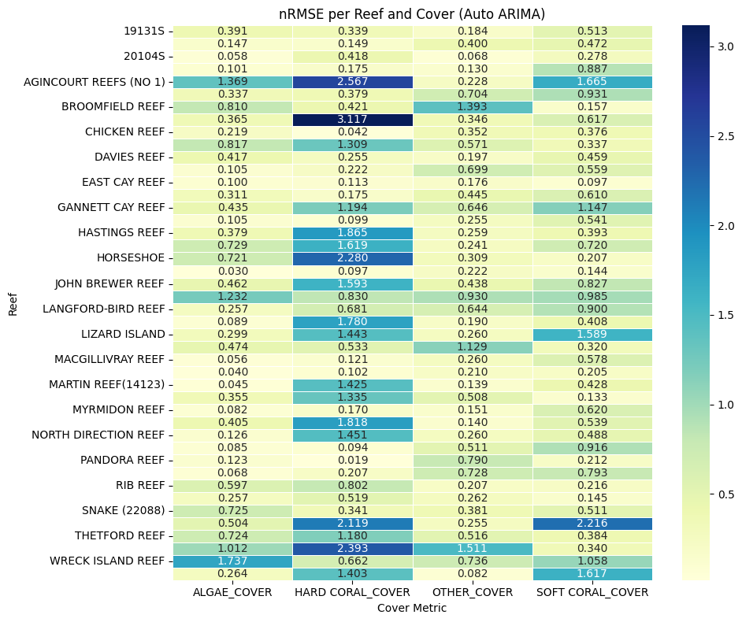

```python
# Create a pivot table: "reefs" as rows, "cover metrics" as columns, "nRMSE" as values;
results_df = pd.DataFrame(auto_arima_results)
pivot_table = results_df.pivot(index='REEF_NAME', columns='COVER', values='nRMSE')

# Plot a stylized heatmap;
plt.figure(figsize=(10, 8))
sns.heatmap(pivot_table, annot=True, cmap='YlGnBu', fmt=".3f", linewidths=0.5)
plt.title('nRMSE per Reef and Cover (Auto ARIMA)')
plt.ylabel('Reef')
plt.xlabel('Cover Metric')
plt.tight_layout()
plt.show()
```

Now, for the **challenger model**;

Here is my implementation of **TBATS**, in a similar fashion to what was done with **auto ARIMA**:

```python
cover_cols = [c for c in primary_df_SpI.columns if c.endswith("_COVER")]
reefs = primary_df_SpI['REEF_NAME'].unique()
# Store results in a list;
tbats_results = []

for reef in reefs:
    df_reef = primary_df_SpI.loc[primary_df_SpI['REEF_NAME'] == reef].sort_values('SAMPLE_DATE')
    print(f"Now computing results for reef: {df_reef['REEF_NAME'].iloc[0]}")

    for cover in cover_cols:
        y = df_reef[cover].values
        # Simple train/test split: 80% train, 20% test;
            # (to ensure same conditions as auto ARIMA);
        split_idx = int(len(y)*0.8)
        y_train, y_test = y[:split_idx], y[split_idx:]

        # Fit TBATS model;
        # Will assume a half year seasonality due to seasonal shift (ie. Summer, Autumn, Winter, Spring);
        seasonal_periods = [26]
        tbats_estimator = TBATS(seasonal_periods=seasonal_periods, use_box_cox=False, use_arma_errors=True,
                                use_trend=True, use_damped_trend=True)
        model = tbats_estimator.fit(y_train)
        # Forecast the length of the test set;
        forecast = model.forecast(steps=len(y_test))

        rmse = np.sqrt(mean_squared_error(y_test, forecast))
        nrmse = rmse / (y_test.mean() if y_test.mean() != 0 else 1.0)

        tbats_results.append({
            'REEF_NAME': reef,
            'COVER': cover,
            'nRMSE': nrmse
        })
```

```
Now computing results for reef: 19131S
Now computing results for reef: 19138S
Now computing results for reef: 20104S
Now computing results for reef: 21529S
Now computing results for reef: AGINCOURT REEFS (NO 1)
Now computing results for reef: BORDER ISLAND REEF (NO 1)
Now computing results for reef: BROOMFIELD REEF
Now computing results for reef: CARTER REEF
Now computing results for reef: CHICKEN REEF
Now computing results for reef: CHINAMAN REEF(22102)
Now computing results for reef: DAVIES REEF
Now computing results for reef: DIP REEF
Now computing results for reef: EAST CAY REEF
Now computing results for reef: FITZROY ISLAND REEF
Now computing results for reef: GANNETT CAY REEF
Now computing results for reef: GREEN ISLAND REEF
Now computing results for reef: HASTINGS REEF
Now computing results for reef: HAYMAN ISLAND REEF
Now computing results for reef: HORSESHOE
Now computing results for reef: HYDE REEF
Now computing results for reef: JOHN BREWER REEF
Now computing results for reef: LADY MUSGRAVE REEF
Now computing results for reef: LANGFORD-BIRD REEF
Now computing results for reef: LINNET REEF
Now computing results for reef: LIZARD ISLAND
Now computing results for reef: LOW ISLANDS REEF
Now computing results for reef: MACGILLIVRAY REEF
Now computing results for reef: MACKAY REEF
Now computing results for reef: MARTIN REEF(14123)
Now computing results for reef: MICHAELMAS REEF
Now computing results for reef: MYRMIDON REEF
Now computing results for reef: NO NAME REEF
Now computing results for reef: NORTH DIRECTION REEF
Now computing results for reef: ONE TREE REEF
Now computing results for reef: PANDORA REEF
Now computing results for reef: REBE REEF
Now computing results for reef: RIB REEF
Now computing results for reef: SLATE REEF
Now computing results for reef: SNAKE (22088)
Now computing results for reef: ST CRISPIN REEF
Now computing results for reef: THETFORD REEF
Now computing results for reef: TURNER REEF
Now computing results for reef: WRECK ISLAND REEF
Now computing results for reef: YONGE REEF
```

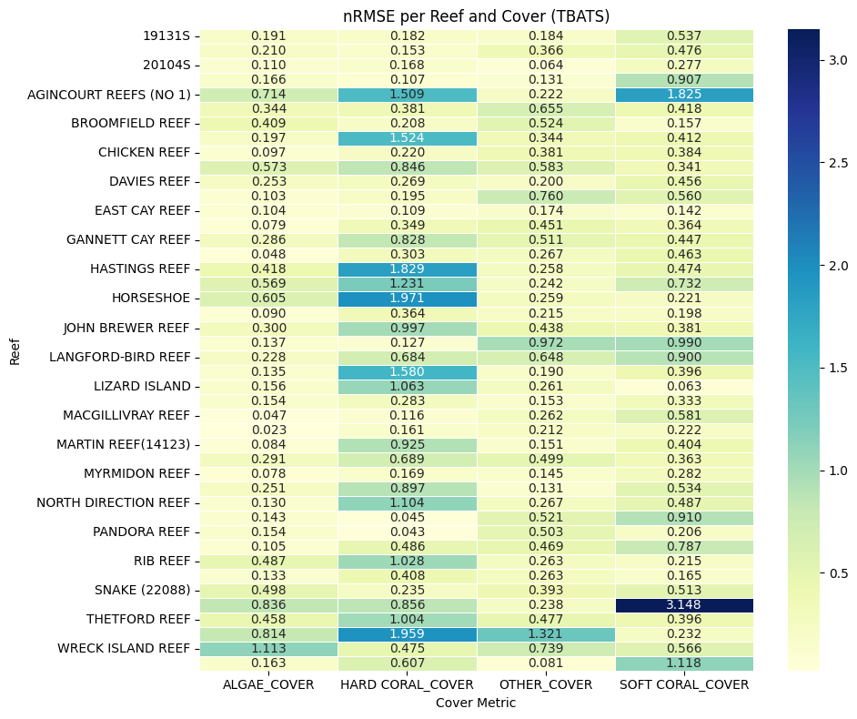

```python
# Create a pivot table: "reefs" as rows, "cover metrics" as columns, "nRMSE" as values;
results_df = pd.DataFrame(tbats_results)
pivot_table = results_df.pivot(index='REEF_NAME', columns='COVER', values='nRMSE')

# Plot a stylized heatmap;
plt.figure(figsize=(10, 8))
sns.heatmap(pivot_table, annot=True, cmap='YlGnBu', fmt=".3f", linewidths=0.5)
plt.title('nRMSE per Reef and Cover (TBATS)')
plt.ylabel('Reef')
plt.xlabel('Cover Metric')
plt.tight_layout()
plt.show()
```

These results aren't much better. More details in the report.

### Multivariate Neural Network on Spline-Based Dataset

Here I will be fitting the **primary interpolated data** onto a **Time Convolutional Network (TCN)**, which should make more granular interpretations on the data at hand *without taking spatial locations into account*:

```python
cover_cols = [c for c in primary_df_SpI.columns if c.endswith("_COVER")]

# Neural network configuration settings;
input_length = 16 # Number of historical steps to use as input;
forecast_horizon = 1 # Predict 1 step into the future;
batch_size = 16
epochs = 20
lr = 0.0005
dropout = 0.1 # Dropout regularisation;
    # (we don't have too much data in the train, about 800 iterations, so this could help with preventing overfitting);
train_split = 0.8 # Train/test split magnitude;
device = torch.device('cuda' if torch.cuda.is_available() else 'cpu')

# Determine cutoff date at 80% quantile;
unique_dates = primary_df_SpI['SAMPLE_DATE'].sort_values().unique()
cutoff_index = int(len(unique_dates) * 0.8)
cutoff_date = unique_dates[cutoff_index]
print("Cutoff date for 80/20 split:", cutoff_date)

# Split into train and test by date;
df_train = primary_df_SpI[primary_df_SpI['SAMPLE_DATE'] <= cutoff_date].copy()
df_test = primary_df_SpI[primary_df_SpI['SAMPLE_DATE'] > cutoff_date].copy()
print("Train set date range:", df_train['SAMPLE_DATE'].min(), "to", df_train['SAMPLE_DATE'].max())
print("Test set date range:", df_test['SAMPLE_DATE'].min(), "to", df_test['SAMPLE_DATE'].max())

# Define the TCN dataset;
class TimeSeriesDataset(Dataset):
    def __init__(self, df, cols, in_len, f_horizon):
        df = df.sort_values(['REEF_NAME','SAMPLE_DATE'])
        self.reefs = df['REEF_NAME'].values
        self.data = df[cols].values.astype(np.float32)
        self.in_len = in_len
        self.f_h = f_horizon

    def __len__(self):
        return max(0, len(self.data)-self.in_len-self.f_h+1)

    def __getitem__(self, i):
        X = self.data[i:i+self.in_len]
        Y = self.data[i+self.in_len:i+self.in_len+self.f_h][0]
        # Reef name at the predicted step
        reef_name = self.reefs[i+self.in_len]
        return X, Y, reef_name

train_ds = TimeSeriesDataset(df_train, cover_cols, input_length, forecast_horizon)
test_ds  = TimeSeriesDataset(df_test, cover_cols, input_length, forecast_horizon)
train_dl = DataLoader(train_ds, batch_size=batch_size, shuffle=True)
test_dl  = DataLoader(test_ds, batch_size=batch_size, shuffle=False)

# TCN model components;
class Chomp1d(nn.Module):
    """Removes extra padding at the end of the sequence to maintain causality."""
    def __init__(self, chomp_size):
        super().__init__()
        self.chomp_size = chomp_size

    def forward(self, x):
        return x[:, :, :-self.chomp_size]

class TemporalBlock(nn.Module):
    """A single temporal block with dilated causal convolutions and residual connection."""
    def __init__(self, n_in, n_out, k, d, drop):
        super().__init__()
        p = (k-1)*d
        self.net = nn.Sequential(
            nn.Conv1d(n_in, n_out, k, dilation=d, padding=p),
            Chomp1d(p),
            nn.ReLU(),
            nn.Dropout(drop),
            nn.Conv1d(n_out, n_out, k, dilation=d, padding=p),
            Chomp1d(p),
            nn.ReLU(),
            nn.Dropout(drop)
        )
        self.downsample = nn.Conv1d(n_in, n_out, 1) if n_in != n_out else None

    def forward(self, x):
        out = self.net(x)
        res = x if self.downsample is None else self.downsample(x)
        return torch.relu(out + res)

class TCN(nn.Module):
    """Temporal Convolutional Network for multivariate forecasting."""
    def __init__(self, in_sz, out_sz, channels=[32,32,32], k=2, drop=0.3):
        super().__init__()
        layers = []
        for i in range(len(channels)):
            dilation = 2**i
            in_ch = in_sz if i == 0 else channels[i-1]
            layers.append(TemporalBlock(in_ch, channels[i], k, dilation, drop))
        self.tcn = nn.Sequential(*layers)
        self.linear = nn.Linear(channels[-1], out_sz)

    def forward(self, x):
        # `x`: [batch, seq_len, features]
        # TCN expects `[batch, features, seq_len]`;
        x = x.permute(0,2,1)
        y = self.tcn(x)[:,:,-1] # Take last time step output;
        return self.linear(y)

# Training;
model = TCN(len(cover_cols), len(cover_cols), drop=dropout).to(device)
opt = torch.optim.Adam(model.parameters(), lr=lr)
crit = nn.MSELoss()
for e in range(epochs):
    model.train()
    train_losses = []
    for X, Y, _ in train_dl: # Ignore `REEF_NAME` during training;
        X, Y = X.to(device), Y.to(device)
        opt.zero_grad()
        out = model(X)
        loss = crit(out, Y)
        loss.backward()
        opt.step()
        train_losses.append(loss.item())
    print(f"Epoch {e+1}/{epochs}, Loss: {np.mean(train_losses):.4f}")

# Evaluation per cover value;
    # (configured to persist `REEF_NAME`);
model.eval()
test_preds, test_trues, test_reefs = [], [], []
with torch.no_grad():
    for X, Y, reef_names in test_dl:
        X, Y = X.to(device), Y.to(device)
        out = model(X)  # out: [batch, num_covers]
        test_preds.append(out.cpu().numpy())
        test_trues.append(Y.cpu().numpy())
        test_reefs.extend(reef_names) # Extend the list with the reef names for each sample;

test_preds = np.concatenate(test_preds, axis=0) # shape: [N, num_covers];
test_trues = np.concatenate(test_trues, axis=0) # shape: [N, num_covers];

# Compute nRMSE per reef and cover;
results = []
for i, reef in enumerate(test_reefs):
    true_row = test_trues[i]
    pred_row = test_preds[i]
    for c_i, c_name in enumerate(cover_cols):
        rmse_i = np.sqrt((true_row[c_i] - pred_row[c_i])**2)
        mean_i = true_row[c_i]
        nrmse_i = rmse_i / (mean_i if mean_i != 0 else 1.0)
        results.append({
            'REEF_NAME': reef,
            'COVER': c_name,
            'nRMSE': nrmse_i
        })
results_df = pd.DataFrame(results)
```

```
Cutoff date for 80/20 split: 2015-07-20 00:00:00
Train set date range: 1994-05-23 00:00:00 to 2015-07-20 00:00:00
Test set date range: 2015-07-27 00:00:00 to 2020-11-02 00:00:00
```

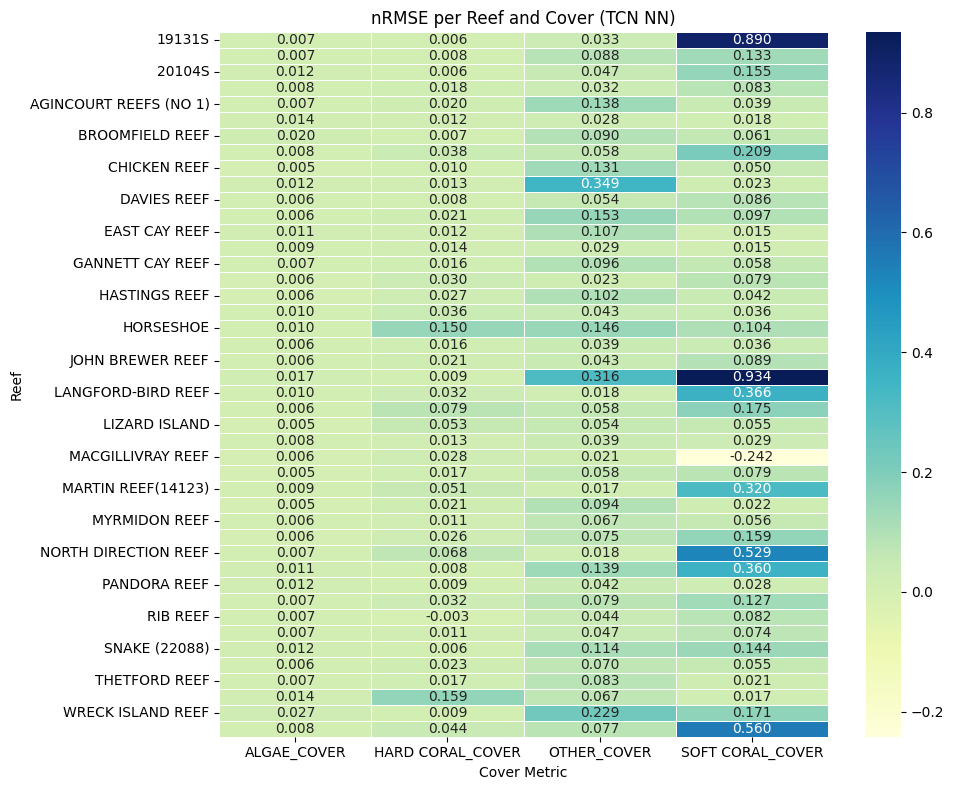

```python
agg_df = results_df.groupby(['REEF_NAME','COVER'])['nRMSE'].mean().reset_index()
pivot_df = agg_df.pivot(index='REEF_NAME', columns='COVER', values='nRMSE')

plt.figure(figsize=(10,8))
sns.heatmap(pivot_df, annot=True, fmt=".3f", cmap='YlGnBu', linewidths=0.5)
plt.title('nRMSE per Reef and Cover (TCN NN)')
plt.ylabel('Reef')
plt.xlabel('Cover Metric')
plt.tight_layout()
plt.show()
```

I found **20 epochs** here to have the most stabilisation.

The results shown here are far, far better than the results given by the **univariate models**, though then again this was somewhat expected. The data we are dealing with is exceptionally complex with **very high multicollinearity** *(something which doesn't rreally work well with **univariate** modelling anyways)*. However, the real question is if the conditions between this test and the auto ARIMA/TBATS test is controlled.

The **TCN model** is **multivariate** and *uses a window of a **variable number of steps** (refer to configuration in code block) of all cover values*, while the **auto ARIMA** was run on each cover individually, the *use of the **same data (and time segments)** plus the **same performance metrics*** means the results are at least meaningfully comparable in terms of how well each approach predicts the next time step.

My only concern right now would be that the model is learning the **"spline interpolation"** and fitting based on that *rather than actually making meaningful **"cover"** predictions*. Though I believe that *since the **evaluation was on a seperate test set rather than on the train set**, the results are still very promising*.

### Building the Spatio-Temporal Graph Neural Network

This is my first attempt at an **ST-GNN** without any auxiliary data whatsoever; this will fit on the full range that **`primary_df_SpI`** provides. This **ST-GNN** will attempt to reinforce the good performance of the **TCN models** *by correlating reef locations by **spatial locations***; in case little to no improvement is seen, that would mean that there wasn't much correlation to be made by location in the first place.

The **temporal NN** here will be the **TCN** used previously to ensure consistency:

```python
cover_cols = [c for c in primary_df_SpI.columns if c.endswith("_COVER")]
primary_df_SpI['SAMPLE_DATE'] = pd.to_datetime(primary_df_SpI['SAMPLE_DATE'])

# Configuration;
    # (I will attempt to keep as many things the same as the previous section for the sake of comparison);
    # (I did however notice that normalization was necessary for this type of neural network based off of the initial results I was getting);
input_length = 16
forecast_horizon = 1
batch_size = 16
epochs = 20
lr = 0.0005
dropout = 0.1
k_neighbors = 5
weight_decay = 1e-4
device = torch.device('cuda' if torch.cuda.is_available() else 'cpu')

# 80/20 temporal split;
unique_dates = primary_df_SpI['SAMPLE_DATE'].sort_values().unique()
cutoff_index = int(len(unique_dates)*0.8)
cutoff_date = unique_dates[cutoff_index]
print("Cutoff date for 80/20 split:", cutoff_date)

df_train = primary_df_SpI[primary_df_SpI['SAMPLE_DATE'] <= cutoff_date].copy()
df_test  = primary_df_SpI[primary_df_SpI['SAMPLE_DATE'] > cutoff_date].copy()

# Compute normalization stats on training data;
train_means = df_train[cover_cols].mean()
train_stds = df_train[cover_cols].std().replace(0, 1.0) # Avoid division by zero;

# Normalize both train and test sets;
df_train[cover_cols] = (df_train[cover_cols] - train_means) / train_stds
df_test[cover_cols] = (df_test[cover_cols] - train_means) / train_stds

# Extract reefs & build graph;
reefs = primary_df_SpI[['REEF_NAME','LATITUDE','LONGITUDE']].drop_duplicates()
reefs = reefs.sort_values('REEF_NAME').reset_index(drop=True)
reef_to_idx = {r: i for i, r in enumerate(reefs['REEF_NAME'])}
idx_to_reef = {v: k for k,v in reef_to_idx.items()}

coords = reefs[['LATITUDE','LONGITUDE']].values
nbrs = NearestNeighbors(n_neighbors=k_neighbors+1).fit(coords)
distances, indices = nbrs.kneighbors(coords)
edge_list = []
for i in range(len(coords)):
    for n in indices[i][1:]:
        edge_list.append([i,n])
        edge_list.append([n,i])
edge_index = torch.tensor(edge_list, dtype=torch.long).t().contiguous()

# Define the ST-GNN dataset;
class STGNNDataset(Dataset):
    def __init__(self, df, cover_cols, in_len, f_horizon, reef_to_idx):
        self.in_len = in_len
        self.f_h = f_horizon
        df = df.sort_values(['SAMPLE_DATE','REEF_NAME'])

        times = df['SAMPLE_DATE'].unique()
        times = np.sort(times)
        df['node_idx'] = df['REEF_NAME'].map(reef_to_idx)
        node_count = len(reef_to_idx)

        X_list = []
        valid_times = []
        for t in times:
            slice_t = df[df['SAMPLE_DATE']==t]
            # Ensure all nodes present
            if len(slice_t)==node_count:
                slice_t = slice_t.sort_values('node_idx')
                X_list.append(slice_t[cover_cols].values.astype(np.float32))
                valid_times.append(t)

        self.X = np.stack(X_list, axis=0) # [T, N, F]
        self.times = valid_times

    def __len__(self):
        return max(0, len(self.X)-self.in_len-self.f_h+1)

    def __getitem__(self, idx):
        X_seq = self.X[idx:idx+self.in_len]
        Y_seq = self.X[idx+self.in_len:idx+self.in_len+self.f_h]
        return X_seq, Y_seq[0]

train_ds = STGNNDataset(df_train, cover_cols, input_length, forecast_horizon, reef_to_idx)
test_ds  = STGNNDataset(df_test, cover_cols, input_length, forecast_horizon, reef_to_idx)
train_dl = DataLoader(train_ds, batch_size=batch_size, shuffle=True)
test_dl = DataLoader(test_ds, batch_size=batch_size, shuffle=False)

class Chomp1d(nn.Module):
    def __init__(self, chomp_size):
        super().__init__()
        self.chomp_size = chomp_size
    def forward(self, x):
        return x[:, :, :-self.chomp_size]

class TemporalBlock(nn.Module):
    def __init__(self, n_in, n_out, k, d, drop):
        super().__init__()
        p = (k-1)*d
        self.net = nn.Sequential(
            nn.Conv1d(n_in, n_out, k, dilation=d, padding=p),
            Chomp1d(p),
            nn.ReLU(),
            nn.Dropout(drop),
            nn.Conv1d(n_out, n_out, k, dilation=d, padding=p),
            Chomp1d(p),
            nn.ReLU(),
            nn.Dropout(drop)
        )
        self.downsample = nn.Conv1d(n_in, n_out, 1) if n_in!=n_out else None
    def forward(self, x):
        out = self.net(x)
        res = x if self.downsample is None else self.downsample(x)
        return torch.relu(out+res)

class TCN(nn.Module):
    def __init__(self, in_sz, out_sz, channels=[32,32,32], k=2, drop=0.3):
        super().__init__()
        layers = []
        for i in range(len(channels)):
            dilation = 2**i
            in_ch = in_sz if i==0 else channels[i-1]
            layers.append(TemporalBlock(in_ch, channels[i], k, dilation, drop))
        self.tcn = nn.Sequential(*layers)
        self.linear = nn.Linear(channels[-1], out_sz)
    def forward(self, x):
        x = x.permute(0,2,1)
        y = self.tcn(x)[:,:,-1]
        y = self.linear(y)
        return y

class STGNN(nn.Module):
    def __init__(self, num_nodes, in_features, out_features, edge_index, hidden_graph=32, temporal_channels=[32,32,32], dropout=0.1):
        super().__init__()
        self.gconv = GCNConv(in_features, hidden_graph)
        self.tcn = TCN(hidden_graph, out_features, channels=temporal_channels, drop=dropout)
        self.edge_index = edge_index.to(device)
        self.num_nodes = num_nodes

    def forward(self, X):
        B, seq, N, F = X.size()
        X = X.to(device)

        X_spatial = []
        for t in range(seq):
            x_t = X[:, t, :, :] # [B, N, F]
            x_t = x_t.reshape(B*N, F)
            # Apply GCN per sample:
            x_g_list = []
            for b_i in range(B):
                node_feats = x_t[b_i*N:(b_i+1)*N]
                node_feats = self.gconv(node_feats, self.edge_index)
                x_g_list.append(node_feats)
            x_g = torch.stack(x_g_list, dim=0) # [B, N, hidden_graph]
            X_spatial.append(x_g)

        X_spatial = torch.stack(X_spatial, dim=1) # [B, seq, N, hidden_graph]

        # Node-wise TCN
        BN = B*N
        X_t = X_spatial.reshape(BN, seq, -1)
        out = self.tcn(X_t) # [B*N, out_features]
        out = out.reshape(B, N, -1) # [B, N, F_out]
        return out

num_nodes = len(reefs)
in_features = len(cover_cols)
out_features = len(cover_cols)

model = STGNN(num_nodes, in_features, out_features, edge_index, hidden_graph=32, temporal_channels=[32,32,32], dropout=dropout).to(device)
opt = torch.optim.Adam(model.parameters(), lr=lr, weight_decay=weight_decay)
crit = nn.MSELoss()

for e in range(epochs):
    model.train()
    train_losses = []
    for X_seq, Y_seq in train_dl:
        X_seq, Y_seq = X_seq.to(device), Y_seq.to(device)
        opt.zero_grad()
        out = model(X_seq)
        loss = crit(out, Y_seq)
        loss.backward()
        opt.step()
        train_losses.append(loss.item())
    print(f"Epoch {e+1}/{epochs}, Loss: {np.mean(train_losses):.4f}")

model.eval()
test_preds, test_trues = [], []
with torch.no_grad():
    for X_seq, Y_seq in test_dl:
        X_seq, Y_seq = X_seq.to(device), Y_seq.to(device)
        pred = model(X_seq)
        test_preds.append(pred.cpu().numpy())
        test_trues.append(Y_seq.cpu().numpy())

test_preds = np.concatenate(test_preds, axis=0) # [M, N, F]
test_trues = np.concatenate(test_trues, axis=0) # [M, N, F]

# Denormalize predictions and truths;
test_preds = (test_preds * train_stds.values) + train_means.values
test_trues = (test_trues * train_stds.values) + train_means.values

results = []
for node_idx in range(num_nodes):
    reef_name = idx_to_reef[node_idx]
    for c_i, c_name in enumerate(cover_cols):
        true_vals = test_trues[:, node_idx, c_i]
        pred_vals = test_preds[:, node_idx, c_i]
        rmse = np.sqrt(mean_squared_error(true_vals, pred_vals))
        mean_val = true_vals.mean()
        nrmse = rmse / (mean_val if mean_val!=0 else 1.0)
        results.append({
            'REEF_NAME': reef_name,
            'COVER': c_name,
            'nRMSE': nrmse
        })
results_df = pd.DataFrame(results)
```

[output not shown]

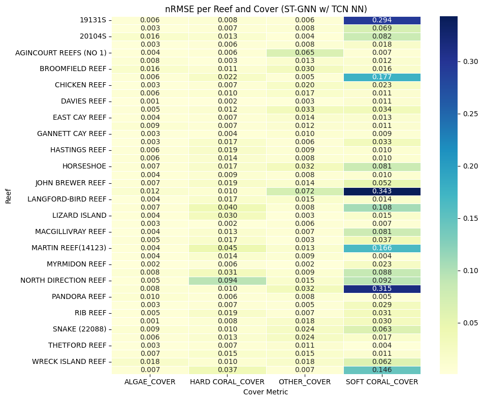

```python
agg_df = results_df.groupby(['REEF_NAME','COVER'])['nRMSE'].mean().reset_index()
pivot_df = agg_df.pivot(index='REEF_NAME', columns='COVER', values='nRMSE')

plt.figure(figsize=(10,8))
sns.heatmap(pivot_df, annot=True, fmt=".3f", cmap='YlGnBu', linewidths=0.5)
plt.title('nRMSE per Reef and Cover (ST-GNN w/ TCN NN)')
plt.ylabel('Reef')
plt.xlabel('Cover Metric')
plt.tight_layout()
plt.show()
```

We see here how the **benthic coral reef shifting** is generalised and fitted a lot better when **spatial locations** are taken into consideration through an **ST-GNN** and the **TCN** which has already been clarified. More details in the report.

Here is a quick visualisation of what the **spatial graph** that the **ST-GNN** compiled looks like:

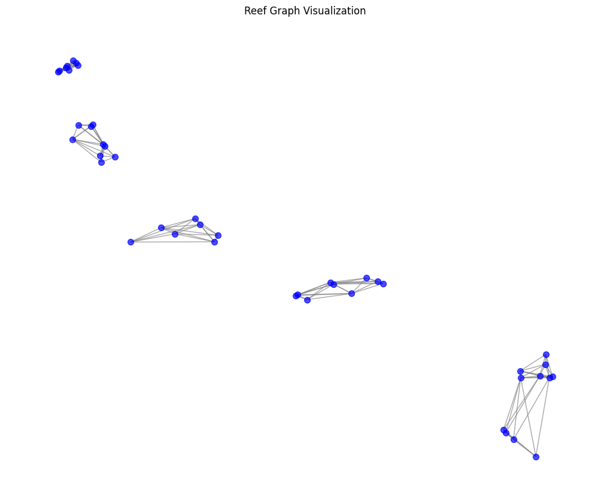

```python
# Define reefs properly;
reefs = primary_df_SpI[['REEF_NAME','LATITUDE','LONGITUDE']].drop_duplicates().sort_values('REEF_NAME')

# Create a graph from `edge_index`;
G = nx.Graph()
num_nodes = len(reefs)
# Add all nodes to the graph;
for i in range(num_nodes):
    lat = reefs.iloc[i]['LATITUDE']
    lon = reefs.iloc[i]['LONGITUDE']
    # Add node with position as attribute (for plotting);
    G.add_node(i, pos=(lon, lat)) # Use (lon, lat) so x=Longitude, y=Latitude;

# Add edges from `edge_index`;
edge_array = edge_index.cpu().numpy() # Ensure it's on CPU if needed;
for i in range(edge_array.shape[1]):
    src, dst = edge_array[0, i], edge_array[1, i]
    G.add_edge(src, dst)

# Extract node positions for plotting;
pos = nx.get_node_attributes(G, 'pos')

plt.figure(figsize=(10,8))
nx.draw(
    G, pos,
    node_size=50,
    node_color='blue',
    with_labels=False,
    edge_color='gray',
    alpha=0.7
)

plt.title("Reef Graph Visualization")
plt.figure(figsize=(5, 3))
plt.show()
```